# Assignment_3

Cole Yagersz

## Introduction

Please answer all questions from 1 to 3. You should use R to solve the questions and include the screenshots in your submission. The Golden questions are optional and carries additional marks. This means that you will not lose marks if you do not answer that question. Your solution should include the calculation steps and your conclusion that is clearly expressed.

## Question 1

Run the following code in R-studio to create two variables X and Y.

set.seed(2017)

X=runif(100)*10

Y=X*4+3.45

Y=rnorm(100)*0.29*Y+Y

```r
set.seed(2017)
X=runif(100)*10
Y=X*4+3.45
Y=rnorm(100)*0.29*Y+Y
```

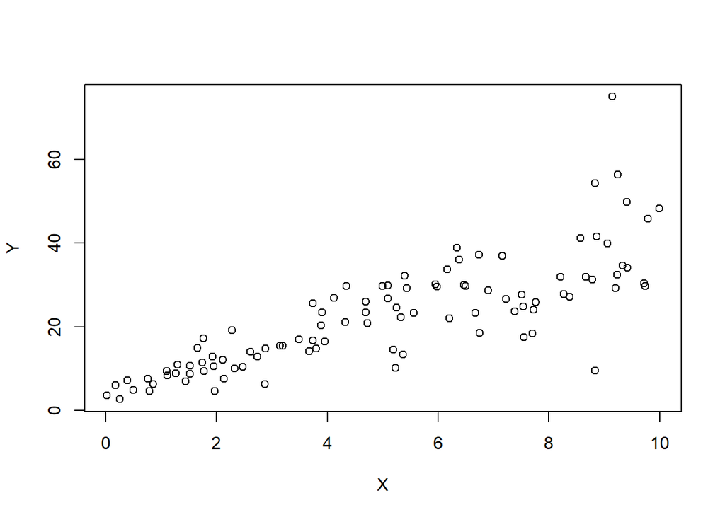

```r
# Question 1.a
plot(Y ~ X)
```

I think based off the chart displayed from Y based of X a linear model would be a good choice because as X increase so does Y showing a positive linear relationship between the variables.

```r
# Question 1.b
model1 <- lm(Y ~ X)
summary(model1)
```

```
##
## Call:
## lm(formula = Y ~ X)
##
## Residuals:
##     Min      1Q  Median      3Q     Max
## -26.755  -3.846  -0.387   4.318  37.503
##
## Coefficients:
##             Estimate Std. Error t value Pr(>|t|)
## (Intercept)   4.4655     1.5537   2.874  0.00497 **
## X             3.6108     0.2666  13.542  < 2e-16 ***
## ---
## Signif. codes:  0 '***' 0.001 '**' 0.01 '*' 0.05 '.' 0.1 ' ' 1
##
## Residual standard error: 7.756 on 98 degrees of freedom
## Multiple R-squared:  0.6517, Adjusted R-squared:  0.6482
## F-statistic: 183.4 on 1 and 98 DF,  p-value: < 2.2e-16
```

```r
# Question 1.c

cat("The correlation coefficient is", cor(X, Y)^2, "\n")
```

```
## The correlation coefficient is 0.6517187
```

```r
cat("The correlation of Determination is", summary(model1)$r.squared)
```

```
## The correlation of Determination is 0.6517187
```

## Question 2

We will use the ‘mtcars’ dataset for this question. The dataset is already included in your R distribution. The dataset shows some of the characteristics of different cars. The following shows few samples (i.e. the first 6 rows) of the dataset.

```r
head(mtcars)
```

```
##                    mpg cyl disp  hp drat    wt  qsec vs am gear carb
## Mazda RX4         21.0   6  160 110 3.90 2.620 16.46  0  1    4    4
## Mazda RX4 Wag     21.0   6  160 110 3.90 2.875 17.02  0  1    4    4
## Datsun 710        22.8   4  108  93 3.85 2.320 18.61  1  1    4    1
## Hornet 4 Drive    21.4   6  258 110 3.08 3.215 19.44  1  0    3    1
## Hornet Sportabout 18.7   8  360 175 3.15 3.440 17.02  0  0    3    2
## Valiant           18.1   6  225 105 2.76 3.460 20.22  1  0    3    1
```

```r
# Question 2.a
James <- lm(hp ~ wt, data = mtcars)
Chris <- lm(hp ~ mpg, data = mtcars)

summary(James)
```

```
##
## Call:
## lm(formula = hp ~ wt, data = mtcars)
##
## Residuals:
##     Min      1Q  Median      3Q     Max
## -83.430 -33.596 -13.587   7.913 172.030
##
## Coefficients:
##             Estimate Std. Error t value Pr(>|t|)
## (Intercept)   -1.821     32.325  -0.056    0.955
## wt            46.160      9.625   4.796 4.15e-05 ***
## ---
## Signif. codes:  0 '***' 0.001 '**' 0.01 '*' 0.05 '.' 0.1 ' ' 1
##
## Residual standard error: 52.44 on 30 degrees of freedom
## Multiple R-squared:  0.4339, Adjusted R-squared:  0.4151
## F-statistic:    23 on 1 and 30 DF,  p-value: 4.146e-05
```

```r
cat("The correlation of Determination is", summary(James)$r.squared, "\n")
```

```
## The correlation of Determination is 0.4339488
```

```r
summary(Chris)
```

```
##
## Call:
## lm(formula = hp ~ mpg, data = mtcars)
##
## Residuals:
##    Min     1Q Median     3Q    Max
## -59.26 -28.93 -13.45  25.65 143.36
##
## Coefficients:
##             Estimate Std. Error t value Pr(>|t|)
## (Intercept)   324.08      27.43  11.813 8.25e-13 ***
## mpg            -8.83       1.31  -6.742 1.79e-07 ***
## ---
## Signif. codes:  0 '***' 0.001 '**' 0.01 '*' 0.05 '.' 0.1 ' ' 1
##
## Residual standard error: 43.95 on 30 degrees of freedom
## Multiple R-squared:  0.6024, Adjusted R-squared:  0.5892
## F-statistic: 45.46 on 1 and 30 DF,  p-value: 1.788e-07
```

```r
cat("The correlation of Determination is", summary(Chris)$r.squared, "\n")
```

```
## The correlation of Determination is 0.6024373
```

Based off the models we have created for James and Chris we got two different correlations. When comparing Horse Power based on Weight (wt) in James model we got a correlation of .4339. So based on that we can say that 43.39% of Horse Power variability is based on weight. In Chris model we compare Horse Power based on Mile Per Gallon (mpg). We got a correlation of .6024. So based on that we can say 60.24% of Horse Power variability is based on Mile Per Gallon. So I would say that Chris is more accurate in saying that the Miles Per Gallon (mpg) is a better estimator in Horse Power (hp).

```r
# Question 2.b
model <- lm(hp ~ cyl+mpg, data = mtcars)
summary(model)
```

```
##
## Call:
## lm(formula = hp ~ cyl + mpg, data = mtcars)
##
## Residuals:
##    Min     1Q Median     3Q    Max
## -53.72 -22.18 -10.13  14.47 130.73
##
## Coefficients:
##             Estimate Std. Error t value Pr(>|t|)
## (Intercept)   54.067     86.093   0.628  0.53492
## cyl           23.979      7.346   3.264  0.00281 **
## mpg           -2.775      2.177  -1.275  0.21253
## ---
## Signif. codes:  0 '***' 0.001 '**' 0.01 '*' 0.05 '.' 0.1 ' ' 1
##
## Residual standard error: 38.22 on 29 degrees of freedom
## Multiple R-squared:  0.7093, Adjusted R-squared:  0.6892
## F-statistic: 35.37 on 2 and 29 DF,  p-value: 1.663e-08
```

```r
cat("The predicted Horse Power of the car with 4 cylinders and 22 Miles Per Gallon is ",predict(model,data.frame(cyl = c(4), mpg = c(22))))
```

```
## The predicted Horse Power of the car with 4 cylinders and 22 Miles Per Gallon is  88.93618
```

## Question 3

For this question, we are going to use BostonHousing dataset. The dataset is in ‘mlbench’ package, so we first need to install the package, call the library and the load the dataset using the following commands

```r
library(mlbench)
data(BostonHousing)
```

Build a model to estimate the median value of owner-occupied homes (medv)based on the following variables: crime crate (crim), proportion of residential land zoned for lots over 25,000 sq.ft (zn), the local pupil-teacher ratio (ptratio) and weather the whether the tract bounds Chas River(chas). Is this an accurate model? (Hint check R 2 )

```r
# Question 3.a
homes_model <- lm(medv ~ crim+zn+ptratio+chas, data = BostonHousing)
summary(homes_model)
```

```
##
## Call:
## lm(formula = medv ~ crim + zn + ptratio + chas, data = BostonHousing)
##
## Residuals:
##     Min      1Q  Median      3Q     Max
## -18.282  -4.505  -0.986   2.650  32.656
##
## Coefficients:
##             Estimate Std. Error t value Pr(>|t|)
## (Intercept) 49.91868    3.23497  15.431  < 2e-16 ***
## crim        -0.26018    0.04015  -6.480 2.20e-10 ***
## zn           0.07073    0.01548   4.570 6.14e-06 ***
## ptratio     -1.49367    0.17144  -8.712  < 2e-16 ***
## chas1        4.58393    1.31108   3.496 0.000514 ***
## ---
## Signif. codes:  0 '***' 0.001 '**' 0.01 '*' 0.05 '.' 0.1 ' ' 1
##
## Residual standard error: 7.388 on 501 degrees of freedom
## Multiple R-squared:  0.3599, Adjusted R-squared:  0.3547
## F-statistic: 70.41 on 4 and 501 DF,  p-value: < 2.2e-16
```

```r
cat(" The accuracy of this model is",summary(homes_model)$r.squared)
```

```
##  The accuracy of this model is 0.359859
```

The accuracy of this model is 35.98% which is not as accurate as it should be to be called a reliable model to say that the median value of the homes are based on crime crate (crim), proportion of residential land zoned for lots over25,000 sq.ft (zn), the local pupil-teacher ratio (ptratio) and weather the whether the tract bounds Chas River(chas). So overall I would say that this is not an accurate model.

Question 3.b

Part 1: From the estimated model we see that the coefficient for chas is 4.583. That means holding all the other variables constant a house on Charles river is predicted to be around $4,500 more than a house not by Charles river. So the conclusion is that a house with in the area of Charles river will be more expensive than a identical house not in the same area.

Part 2: So the estimated coefficient for ptratio is -1.493. So taking that we can multiply that by the difference of the pupil-teacher (18-15)=3. (-1.493)*(3)=(-4.479). So the house in the area where the pupil teacher is lower is going to have more expensive housing by $4,479.

Question 3.c

All the variables fit the criteria to be statically important they all have a p value lower than .05 making them all important in determining the median home value (medv).

Question 3.d

```r
imp_var <- anova(homes_model)
imp_var
```

```
## Analysis of Variance Table
##
## Response: medv
##            Df  Sum Sq Mean Sq F value    Pr(>F)
## crim        1  6440.8  6440.8 118.007 < 2.2e-16 ***
## zn          1  3554.3  3554.3  65.122 5.253e-15 ***
## ptratio     1  4709.5  4709.5  86.287 < 2.2e-16 ***
## chas        1   667.2   667.2  12.224 0.0005137 ***
## Residuals 501 27344.5    54.6
## ---
## Signif. codes:  0 '***' 0.001 '**' 0.01 '*' 0.05 '.' 0.1 ' ' 1
```

Based on the anova analysis we can rank the importance of the variables based on the Sum sq.

1. crime crate (crim) 6440.8
2. pupil teacher (ptratio) 4709.5

3.land zoned for lots over 25,000 sq ft (zn) 3554.3

4. tract bounds Chas River(chas) 667.2